# Análisis de datos de fertilidad

Ana Paula Solórzano

2026-06-30

### Descarga del conjunto de datos

El conjunto de datos utilizado en este análisis fue obtenido de la plataforma Kaggle, específicamente del repositorio *Fertility Data Set*.

[*Fertility Data Set en Kaggle*](https://www.kaggle.com/datasets/muhamedyoussry/fertility-data-set)

A continuación, se cargan los datos en R y se visualizan las primeras observaciones del conjunto de datos:

```r
library(tidyverse)
fertilidad <- read.csv("~/R Studio/Code & Data Bootcamp/proyecto_final/data/fertility.csv")
head(fertilidad)
```

```
##   Season Age Childish.diseases Accident.or.serious.trauma Surgical.intervention
## 1 spring  30                no                        yes                   yes
## 2 spring  35               yes                         no                   yes
## 3 spring  27               yes                         no                    no
## 4 spring  32                no                        yes                   yes
## 5 spring  30               yes                        yes                    no
## 6 spring  30               yes                         no                   yes
##   High.fevers.in.the.last.year Frequency.of.alcohol.consumption Smoking.habit
## 1       more than 3 months ago                      once a week    occasional
## 2       more than 3 months ago                      once a week         daily
## 3       more than 3 months ago             hardly ever or never         never
## 4       more than 3 months ago             hardly ever or never         never
## 5       more than 3 months ago                      once a week         never
## 6       more than 3 months ago                      once a week    occasional
##   Number.of.hours.spent.sitting.per.day Diagnosis
## 1                                    16    Normal
## 2                                     6   Altered
## 3                                     9    Normal
## 4                                     7    Normal
## 5                                     9   Altered
## 6                                     9    Normal
```

### Descripción de los datos

**Dimensiones del dataframe**

```r
dim(fertilidad)
```

```
## [1] 100  10
```

El conjunto de datos está compuesto por 100 filas y 10 columnas.

**Nombres de las columnas**

```r
names(fertilidad)
```

```
##  [1] "Season"
##  [2] "Age"
##  [3] "Childish.diseases"
##  [4] "Accident.or.serious.trauma"
##  [5] "Surgical.intervention"
##  [6] "High.fevers.in.the.last.year"
##  [7] "Frequency.of.alcohol.consumption"
##  [8] "Smoking.habit"
##  [9] "Number.of.hours.spent.sitting.per.day"
## [10] "Diagnosis"
```

**Tipo de variables en cada columna**

```r
str(fertilidad)
```

```
## 'data.frame':    100 obs. of  10 variables:
##  $ Season                               : chr  "spring" "spring" "spring" "spring" ...
##  $ Age                                  : int  30 35 27 32 30 30 30 36 30 29 ...
##  $ Childish.diseases                    : chr  "no" "yes" "yes" "no" ...
##  $ Accident.or.serious.trauma           : chr  "yes" "no" "no" "yes" ...
##  $ Surgical.intervention                : chr  "yes" "yes" "no" "yes" ...
##  $ High.fevers.in.the.last.year         : chr  "more than 3 months ago" "more than 3 months ago" "more than 3 months ago" "more than 3 months ago" ...
##  $ Frequency.of.alcohol.consumption     : chr  "once a week" "once a week" "hardly ever or never" "hardly ever or never" ...
##  $ Smoking.habit                        : chr  "occasional" "daily" "never" "never" ...
##  $ Number.of.hours.spent.sitting.per.day: int  16 6 9 7 9 9 8 7 5 5 ...
##  $ Diagnosis                            : chr  "Normal" "Altered" "Normal" "Normal" ...
```

La mayoría de las variables corresponden a datos de tipo carácter (`chr`) y numéricos enteros (`int`).

### Preguntas de análisis de datos

#### ¿Existe una diferencia en la edad entre las personas con diagnóstico normal y alterado de fertilidad?

Se realiza un resumen de los datos agrupando por edad y diagnóstico:

```r
edad_fertilidad <- fertilidad %>%
  group_by(Age) %>%
  summarise(
    total = n(),
    normal = sum(Diagnosis == "Normal"),
    alterada = sum(Diagnosis == "Altered"),
    prop_infertilidad = alterada / total,
    porcentaje_normal = normal / total * 100
  ) %>%
  arrange(desc(normal))
edad_fertilidad
```

```
## # A tibble: 10 × 6
##      Age total normal alterada prop_infertilidad porcentaje_normal
##    <int> <int>  <int>    <int>             <dbl>             <dbl>
##  1    28    28     28        0             0                 100
##  2    30    27     20        7             0.259              74.1
##  3    32    17     14        3             0.176              82.4
##  4    33     7      7        0             0                 100
##  5    27     7      6        1             0.143              85.7
##  6    29     5      5        0             0                 100
##  7    35     4      3        1             0.25               75
##  8    31     2      2        0             0                 100
##  9    36     2      2        0             0                 100
## 10    34     1      1        0             0                 100
```

Se complementa el análisis con una visualización de la distribución de la edad según el diagnóstico:

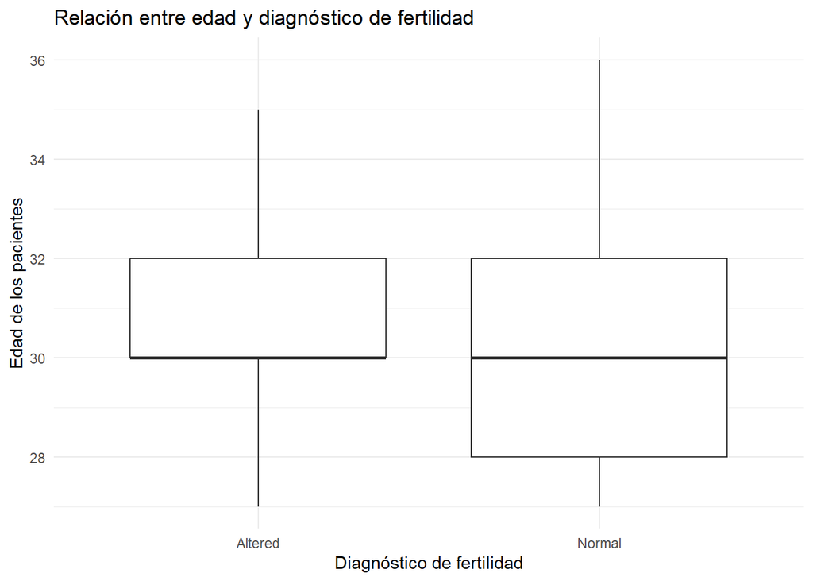

```r
ggplot(data = fertilidad,
       aes(x = Diagnosis,
           y = Age)) +
  geom_boxplot() +
  labs(
    title = "Relación entre edad y diagnóstico de fertilidad",
    x = "Diagnóstico de fertilidad",
    y = "Edad de los pacientes"
  ) +
  theme_minimal()
```

Se observa una diferencia en la distribución de la edad entre los grupos. El grupo “Altered” se concentra en edades ligeramente mayores, aproximadamente entre 30 y 32 años, mientras que el grupo “Normal” presenta una distribución más amplia. Esto sugiere una posible asociación entre mayor edad y diagnóstico de fertilidad alterado.

#### ¿El hábito de fumar está asociado con el diagnóstico de fertilidad?

Se calcula un resumen por hábito de fumar y diagnóstico:

```r
fumar_fertilidad <- fertilidad %>%
  group_by(Smoking.habit) %>%
  summarise(
    total = n(),
    normal = sum(Diagnosis == "Normal"),
    alterada = sum(Diagnosis == "Altered"),
    prop_infertilidad = alterada / total,
    porcentaje_normal = normal / total * 100
    ) %>%
  arrange(desc(porcentaje_normal))
fumar_fertilidad
```

```
## # A tibble: 3 × 6
##   Smoking.habit total normal alterada prop_infertilidad porcentaje_normal
##   <chr>         <int>  <int>    <int>             <dbl>             <dbl>
## 1 never            56     50        6             0.107              89.3
## 2 occasional       23     20        3             0.130              87.0
## 3 daily            21     18        3             0.143              85.7
```

Se analiza la distribución mediante una gráfica de frecuencias:

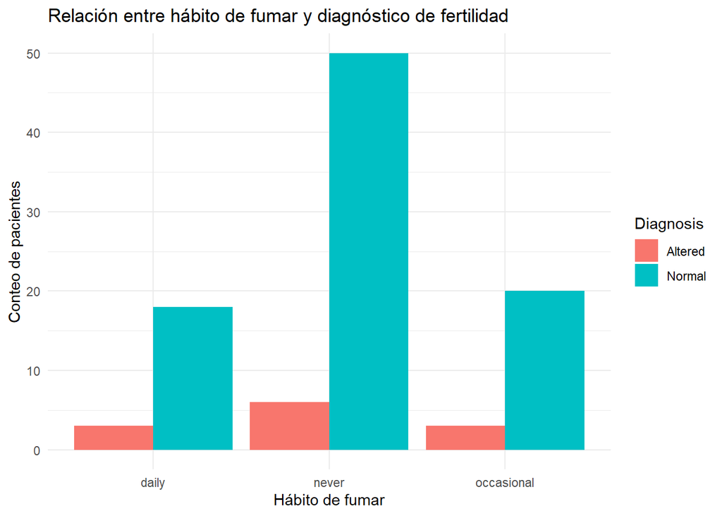

```r
ggplot(data = fertilidad,
       aes(x = Smoking.habit,
           fill = Diagnosis)) +
  geom_bar(position = "dodge") +
  labs(
    title = "Relación entre hábito de fumar y diagnóstico de fertilidad",
    x = "Hábito de fumar",
    y = "Conteo de pacientes"
  ) +
  theme_minimal()
```

Se observa una ligera disminución en el porcentaje de diagnósticos de fertilidad normal conforme aumenta la frecuencia de consumo de tabaco, con valores más altos en no fumadores (89.3%) y más bajos en fumadores diarios (85.7%).

#### ¿La frecuencia de consumo de alcohol está asociada con el diagnóstico de fertilidad?

Se realiza un resumen de los datos según la frecuencia de consumo de alcohol y el diagnóstico de fertilidad:

```r
alcohol_fertilidad <- fertilidad %>%
  group_by(Frequency.of.alcohol.consumption) %>%
  summarise(
    total = n(),
    normal = sum(Diagnosis == "Normal"),
    alterada = sum(Diagnosis == "Altered"),
    prop_infertilidad = alterada / total,
    porcentaje_normal = normal / total * 100
    ) %>%
  arrange(desc(normal))
alcohol_fertilidad
```

```
## # A tibble: 5 × 6
##   Frequency.of.alcohol.consumption total normal alterada prop_infertilidad
##   <chr>                            <int>  <int>    <int>             <dbl>
## 1 hardly ever or never                40     38        2             0.05
## 2 once a week                         39     33        6             0.154
## 3 several times a week                19     15        4             0.211
## 4 every day                            1      1        0             0
## 5 several times a day                  1      1        0             0
## # ℹ 1 more variable: porcentaje_normal <dbl>
```

Posteriormente, se visualiza la proporción de diagnósticos según la frecuencia de consumo de alcohol:

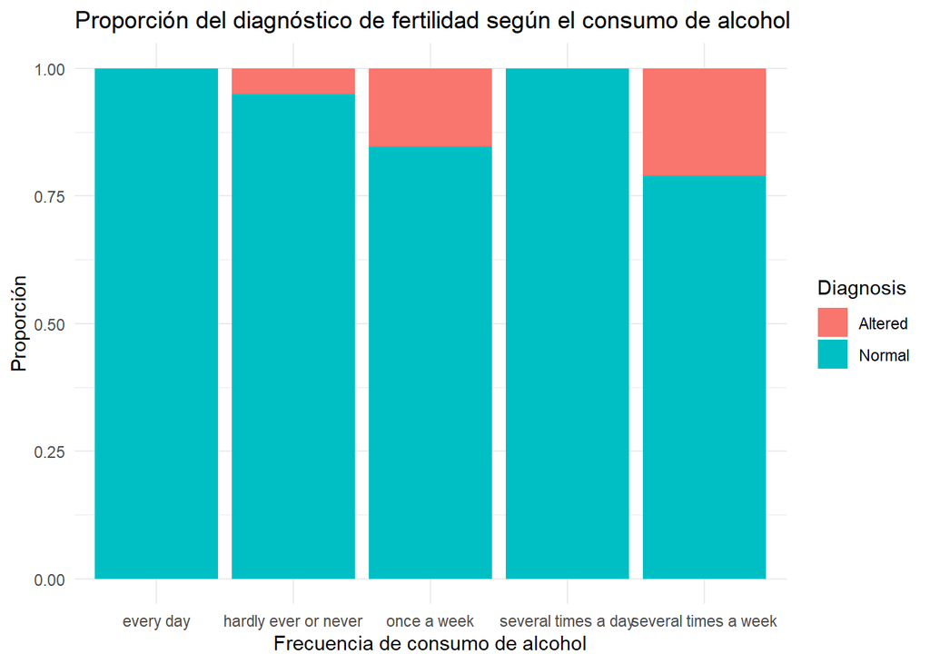

```r
ggplot(fertilidad,
       aes(x = Frequency.of.alcohol.consumption,
           fill = Diagnosis)) +
  geom_bar(position = "fill") +
  labs(
    title = "Proporción del diagnóstico de fertilidad según el consumo de alcohol",
    x = "Frecuencia de consumo de alcohol",
    y = "Proporción"
  ) +
  theme_minimal()
```

Se observa que la mayoría de los pacientes presentan un diagnóstico de fertilidad normal, independientemente de la frecuencia de consumo de alcohol. Aunque algunos grupos muestran una proporción ligeramente mayor de diagnósticos alterados, no se aprecia una asociación clara entre el consumo de alcohol y el diagnóstico de fertilidad.

#### ¿Las personas con antecedentes médicos presentan mayor proporción de infertilidad?

Se analiza la relación entre antecedentes médicos y diagnóstico de fertilidad:

```r
medica_fertilidad <- fertilidad %>%
  group_by(Childish.diseases, Accident.or.serious.trauma, Surgical.intervention) %>%
  summarise(
    total = n(),
    normal = sum(Diagnosis == "Normal"),
    infertilidad = sum(Diagnosis == "Altered" ),
    prop_infertilidad = infertilidad / total,
    porcentaje_normal = normal / total * 100)
medica_fertilidad
```

```
## # A tibble: 7 × 8
## # Groups:   Childish.diseases, Accident.or.serious.trauma [4]
##   Childish.diseases Accident.or.serious.tra…¹ Surgical.intervention total normal
##   <chr>             <chr>                     <chr>                 <int>  <int>
## 1 no                no                        no                        4      4
## 2 no                no                        yes                       6      4
## 3 no                yes                       yes                       3      3
## 4 yes               no                        no                       26     24
## 5 yes               no                        yes                      20     15
## 6 yes               yes                       no                       19     16
## 7 yes               yes                       yes                      22     22
## # ℹ abbreviated name: ¹Accident.or.serious.trauma
## # ℹ 3 more variables: infertilidad <int>, prop_infertilidad <dbl>,
## #   porcentaje_normal <dbl>
```

Se crea una variable que agrupa los antecedentes médicos:

```r
fertilidad2 <- fertilidad %>%
  mutate(grupo_antecedentes = paste(
    Childish.diseases,
    Accident.or.serious.trauma,
    Surgical.intervention,
    sep = " | "
  ))
head(fertilidad2)
```

```
##   Season Age Childish.diseases Accident.or.serious.trauma Surgical.intervention
## 1 spring  30                no                        yes                   yes
## 2 spring  35               yes                         no                   yes
## 3 spring  27               yes                         no                    no
## 4 spring  32                no                        yes                   yes
## 5 spring  30               yes                        yes                    no
## 6 spring  30               yes                         no                   yes
##   High.fevers.in.the.last.year Frequency.of.alcohol.consumption Smoking.habit
## 1       more than 3 months ago                      once a week    occasional
## 2       more than 3 months ago                      once a week         daily
## 3       more than 3 months ago             hardly ever or never         never
## 4       more than 3 months ago             hardly ever or never         never
## 5       more than 3 months ago                      once a week         never
## 6       more than 3 months ago                      once a week    occasional
##   Number.of.hours.spent.sitting.per.day Diagnosis grupo_antecedentes
## 1                                    16    Normal     no | yes | yes
## 2                                     6   Altered     yes | no | yes
## 3                                     9    Normal      yes | no | no
## 4                                     7    Normal     no | yes | yes
## 5                                     9   Altered     yes | yes | no
## 6                                     9    Normal     yes | no | yes
```

Se visualiza la distribución del diagnóstico según los antecedentes médicos:

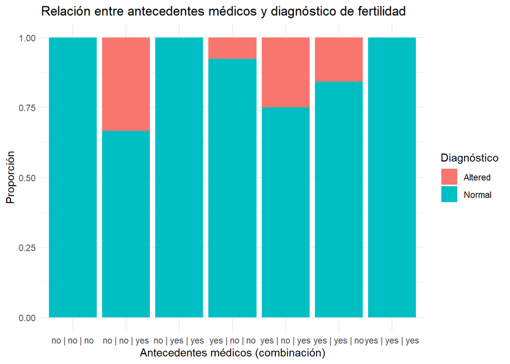

```r
ggplot(fertilidad2,
       aes(x = grupo_antecedentes,
           fill = Diagnosis)) +
  geom_bar(position = "fill") +
  labs(
    x = "Antecedentes médicos (combinación)",
    y = "Proporción",
    fill = "Diagnóstico",
    title = "Relación entre antecedentes médicos y diagnóstico de fertilidad"
  ) +
  theme_minimal()
```

Los resultados sugieren que algunos antecedentes médicos, particularmente las intervenciones quirúrgicas, se asocian con una mayor proporción de diagnósticos alterados de fertilidad. Sin embargo, no se observa una tendencia consistente, por lo que no es posible establecer una relación clara entre estos antecedentes y el diagnóstico de fertilidad.

#### ¿El tiempo sedentario diario cambia según la estación y se asocia con el diagnóstico de fertilidad?

Se calcula el tiempo promedio y la mediana de horas sedentarias por estación del año y diagnóstico de fertilidad:

```r
sedentario_fertilidad <- fertilidad %>%
  group_by(Season, Diagnosis) %>%
  summarise(
    total = n(),
    media_h_sentadas = mean(Number.of.hours.spent.sitting.per.day, na.rm = TRUE),
    mediana_h_sentadas = median(Number.of.hours.spent.sitting.per.day, na.rm = TRUE)
  )

sedentario_fertilidad
```

```
## # A tibble: 8 × 5
## # Groups:   Season [4]
##   Season Diagnosis total media_h_sentadas mediana_h_sentadas
##   <chr>  <chr>     <int>            <dbl>              <dbl>
## 1 fall   Altered       6             7.17                7
## 2 fall   Normal       25             7.32                7
## 3 spring Altered       4             8                   7.5
## 4 spring Normal       33            18.3                 8
## 5 summer Altered       1             8                   8
## 6 summer Normal        3             4.67                6
## 7 winter Altered       1             9                   9
## 8 winter Normal       27             6.93                7
```

Se visualiza la distribución del tiempo sedentario según la estación del año y el diagnóstico:

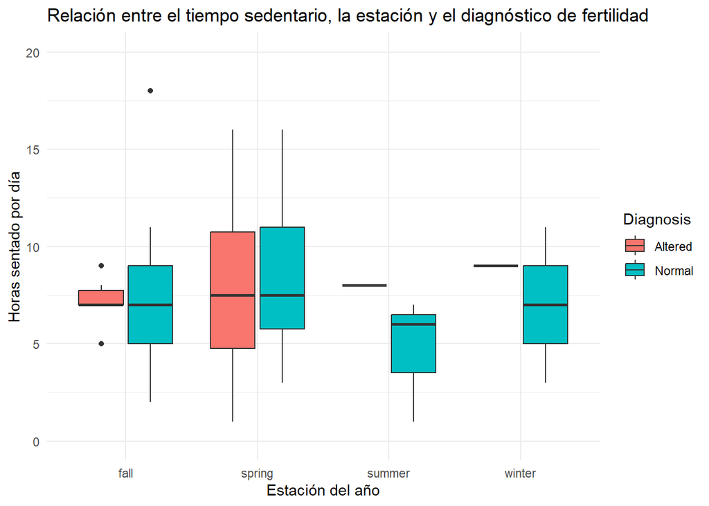

```r
ggplot(fertilidad,
       aes(x = Season,
           y = Number.of.hours.spent.sitting.per.day,
           fill = Diagnosis)) +
  geom_boxplot() +
  labs(
    x = "Estación del año",
    y = "Horas sentado por día",
    title = "Relación entre el tiempo sedentario, la estación y el diagnóstico de fertilidad"
  ) +
  theme_minimal() +
  ylim(0, 20)  # límite establecido para mejorar la visualización
```

El análisis no muestra una asociación clara entre el tiempo de sedentarismo y el diagnóstico de fertilidad. Las medianas son similares entre los grupos con diagnóstico normal y alterado. La media elevada observada en primavera para el grupo con diagnóstico normal se atribuye a la presencia de valores atípicos, por lo que no representa adecuadamente la tendencia central de los datos.